# Analysis of Data / Modelling via Logistic Regression

by Neil Chapman

01/08/2020

## Exploratory Data Analysis (EDA)

Columns within Dataset

- ID :- a unique row ID.
- Organisation :- The organisation the patient was seen at.
- Age :- The patient’s age.
- LOS :- The patent’s length-of-stay in hospital, in whole days.
- Death :- A flag indicating whether the patient died, coded: 0 = survived, 1 = died.
- Category :- The risk category the patient falls into.

### Checking the head and tail of the source file

Quick check on top and tail source file to ensure data looks ok.

```
##   ID Organisation Age LOS Death Category
## 1  1       Trust1  55   2     0      Low
## 2  2       Trust2  27   1     0      Low
## 3  3       Trust3  93  12     0     High
## 4  4       Trust4  45   3     1      Low
## 5  5       Trust5  70  11     0     High
## 6  6       Trust6  60   7     0 Moderate
```

```
##      ID Organisation Age LOS Death Category
## 295 295       Trust5  32   4     0      Low
## 296 296       Trust6  32   6     0      Low
## 297 297       Trust7  55   6     1 Moderate
## 298 298       Trust8  21   3     0      Low
## 299 299       Trust9  54   1     0      Low
## 300 300      Trust10  93  15     0     High
```

### EDA with ‘inspectdf’ library

- Overview of source file structure, type of features within dataset, unique variables etc.
- (source file has been named ‘sim’)

```
##                                 Descriptions      Obs
## 1                         Sample size (Nrow)      300
## 2                    No. of Variables (Ncol)        6
## 3                   No. of Numeric Variables        4
## 4                    No. of Factor Variables        2
## 5                      No. of Text Variables        0
## 6                   No. of Logical Variables        0
## 7                    No. of Unique Variables        1
## 8                      No. of Date Variables        0
## 9   No. of Zero variance Variables (Uniform)        0
## 10     %. of Variables having complete cases 100% (6)
## 11 %. of Variables having <50% missing cases   0% (0)
## 12 %. of Variables having >50% missing cases   0% (0)
## 13 %. of Variables having >90% missing cases   0% (0)
```

```
##   S.no Variable Name Variable Type % of Missing No. of Unique values
## 1    1            ID       integer            0                  300
## 2    2  Organisation        factor            0                   10
## 3    3           Age       integer            0                   88
## 4    4           LOS       integer            0                   16
## 5    5         Death       integer            0                    2
## 6    6      Category        factor            0                    3
```

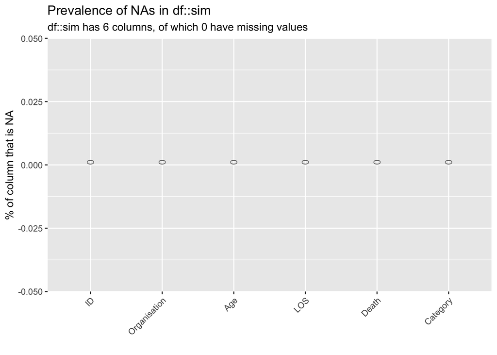

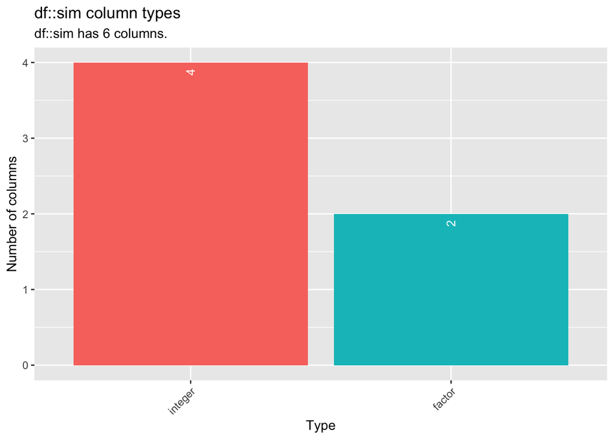

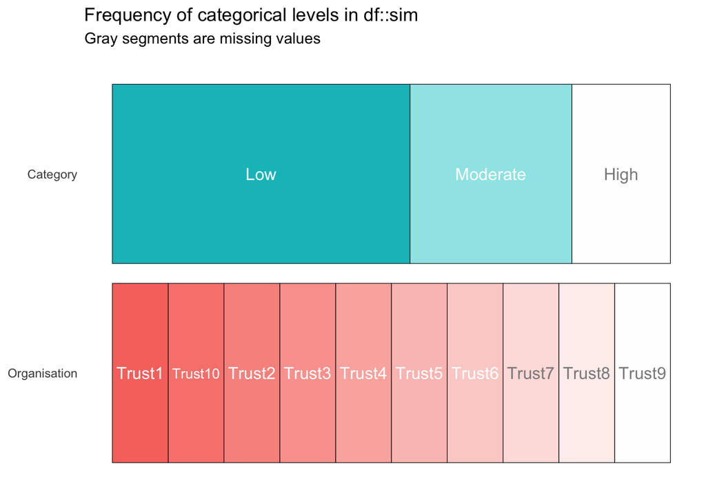

No variables have missing values.

Two Categorical Variables

- Category has 3 possible values (Low, Moderate and High). Low is the dominant value.
- Organisation has ten possible values with equal amounts in each value.

### Alternative EDA, using my own function, eda_v2

```
## [1] "Number of rows in dataset = 300"
## [1] "====================================="
## [1] "Number of Columns in dataset = 6"
## [1] "====================================="
## [1] "Dimensions of Data"
## [1] "=================="
## [1] 300   6
## [1] "Summary of source file using GLIMPSE utility"
## [1] "============================================"
## Rows: 300
## Columns: 6
## $ ID           <int> 1, 2, 3, 4, 5, 6, 7, 8, 9, 10, 11, 12, 13, 14, 15, …
## $ Organisation <fct> Trust1, Trust2, Trust3, Trust4, Trust5, Trust6, Tru…
## $ Age          <int> 55, 27, 93, 45, 70, 60, 25, 48, 51, 81, 58, 16, 21,…
## $ LOS          <int> 2, 1, 12, 3, 11, 7, 4, 4, 7, 1, 4, 3, 1, 9, 12, 1, …
```

[output cut: 53 more lines]

### Checking Distributions of each variable, via Histogram Plots

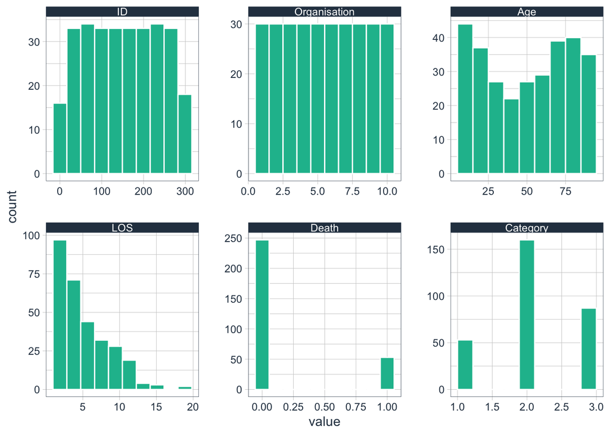

```
## [1] "Death Column - Split between 0 (survived), 1 (Not Survived)"
```

```
##
##   0   1
## 247  53
```

Response Variable (Death) - ie. variable we are trying to predict 247 records have value 0 (survived), 53 have value 1 (not survived)

### Summary of Distributions

- Organisation :- Equally distributed between the ten trusts.
- Age :- Shows more records for younger (< 25) and older (> 60) people
- LOS :- Most length of stays are less than 5 days, longer stays gradually reduce in numbers
- Death :- more records in dataset with value = 0, ie. Survived. This will result in an imbalanced dataset. When modelling this may result in poor performance on minority class. Will use Caret library, to upsample.
- Category :- Risk Category 2 is the most prevalent in this dataset

## Data Preparation

- Converting Death variable to a factor (0 or 1)
- Converting Organisation and Category variables to numeric
- Using the CARET library, split dataset into training and test sets (70/30 split)
- Using CARET library again, addressing the imbalance issue of the response variable (Death). Using upsampling for the minority class, to achieve balanced dataset.
- Feature Scaling, to normalise the range of the independant variables, ahead of modelling.

## Correlation Plot of Variables

- As we are looking at a binary classification problem, eg. does the patient survive or not, then we can utilise the Logistic Regression technique for the modelling phase.
- An assumption of Logistic Regression is that there is no major correlation between independant variables (multicollinearity)
- Producing a correlation plot, to check for this assumption.

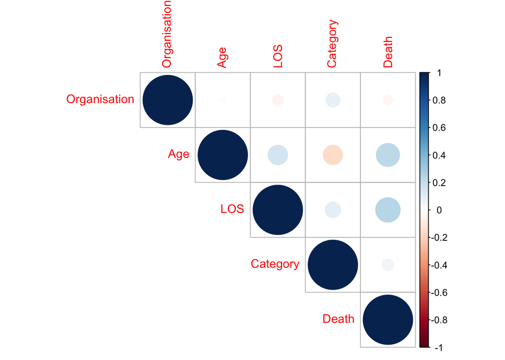

- AGE has a minor positive correlation to the LOS variable. It also has a minor negative correlation with Category.
- These correlations are minor, and would not be considered to invalidate the assumption of no multicollinearity between the independant variables
- Both LOS and AGE, are also showing a minor correlation to the response variable, DEATH. This may indicate that these are important variables for the model.

## Modelling Phase - using Logistic Regression

The initial model will include ALL of the dependant variables, with the ‘Death’ variable, being the response variable we are trying to predict.

To evaluate the model performance, the following will be used :-

- Confusion Matrix (accuracy, precision, specificity metrics)
- ROC Curve / AUC Score

```
##
## Call:
## glm(formula = Death ~ ., family = binomial(link = "logit"), data = up_train)
##
## Deviance Residuals:
##      Min        1Q    Median        3Q       Max
## -1.83469  -1.03418  -0.02404   1.09183   1.72547
##
## Coefficients:
##               Estimate Std. Error z value Pr(>|z|)
## (Intercept)  -0.001541   0.113457  -0.014 0.989161
## Organisation -0.060634   0.112913  -0.537 0.591268
## Age           0.430160   0.118548   3.629 0.000285 ***
## LOS           0.446232   0.117897   3.785 0.000154 ***
## Category      0.146812   0.115280   1.274 0.202832
## ---
## Signif. codes:  0 '***' 0.001 '**' 0.01 '*' 0.05 '.' 0.1 ' ' 1
##
## (Dispersion parameter for binomial family taken to be 1)
##
##     Null deviance: 479.66  on 345  degrees of freedom
## Residual deviance: 443.77  on 341  degrees of freedom
## AIC: 453.77
##
## Number of Fisher Scoring iterations: 4
```

### Model Output notes

Key findings :-

- Organisation and Category variables, are NOT statistically significant (P > 0.05).
- AGE and LOS variables, both statistically significant (p < 0.05).

Based on the above findings, the Organisation and Category variables will be removed, and a new model will then be trained with the just the AGE and LOS variables included (Stepwise regression technique)

So we have a comparison, this initial trained model is now used to predict on the Test Dataset, and the metrics from the confusion matrix and ROC curve analysis will be produced.

### Model 1 Confusion Matrix

```
## [1] "Confusion Matrix"
```

```
##
##     FALSE TRUE
##   0    38   36
##   1     5   10
```

```
## [1] "Accuracy of Model = 0.54"
```

```
## [1] "Precision - When it predicts Survival, how often is it correct ?"
```

```
## [1] "Precision = 0.22"
```

```
## [1] "Specificity - When patient does NOT survive, how often does it predict this ?"
```

```
## [1] "Specificity = 0.51"
```

```
## [1] "Recall / Sensitivity - When patient actually survives, how often does it predict this ?"
```

[output not shown]

### ROC / AUC analysis of Model 1

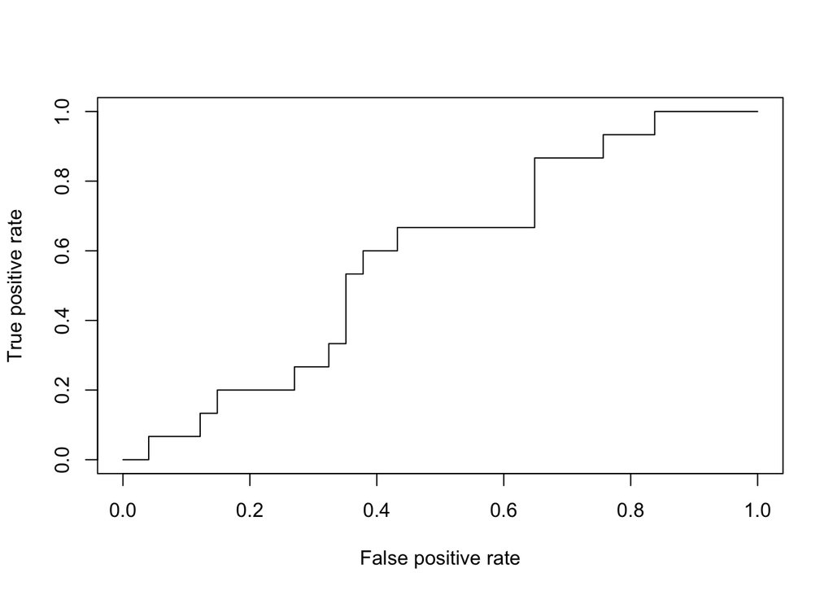

```r
library(ROCR)
ROCRpred = prediction(predictTest, test_set$Death)
# Performance function
ROCRperf = performance(ROCRpred, "tpr", "fpr")
# Plot ROC curve
plot(ROCRperf)
```

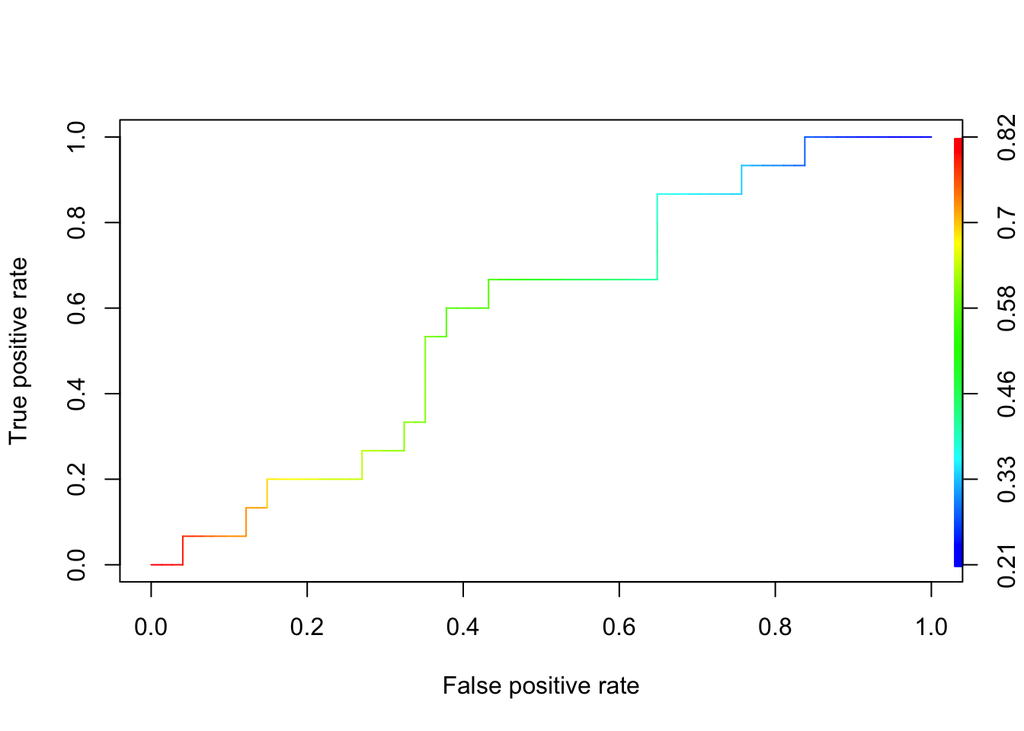

```r
# Add colors
plot(ROCRperf, colorize=TRUE)
```

```r
# Add threshold labels
# plot(ROCRperf, colorize=TRUE, print.cutoffs.at=seq(0,1,by=0.1), text.adj=c(-0.2,1.7))
auc_1 <- auc(test_set$Death,predictTest)
print(paste0("AUC Score for Model 2 = ", auc_1))
```

[output not shown]

A ROC Curve helps determine the accuracy of a Classification model.

A perfect model for a ROC Curve, would have the plot hugging the top left corner of the plot. The nearer the curve is to this, the better the model. Also the higher the AUC value (Area under the curve) the better the model (a perfect model would be equal to 1). A random model would have an AUC value of 0.5 and the curve would be a diagonal splitting the plot into two.

Will now re-create the model, without Organisation and Category variables

### Model 2 - (AGE + LOS only)

```
##
## Call:
## glm(formula = Death ~ Age + LOS, family = binomial(link = "logit"),
##     data = up_train)
##
## Deviance Residuals:
##      Min        1Q    Median        3Q       Max
## -1.90003  -1.04061  -0.02802   1.08219   1.68338
##
## Coefficients:
##              Estimate Std. Error z value  Pr(>|z|)
## (Intercept) 0.0001952  0.1131340   0.002  0.998624
## Age         0.4017092  0.1161091   3.460  0.000541 ***
## LOS         0.4669146  0.1175827   3.971 0.0000716 ***
## ---
## Signif. codes:  0 '***' 0.001 '**' 0.01 '*' 0.05 '.' 0.1 ' ' 1
##
## (Dispersion parameter for binomial family taken to be 1)
##
##     Null deviance: 479.66  on 345  degrees of freedom
## Residual deviance: 445.57  on 343  degrees of freedom
## AIC: 451.57
##
## Number of Fisher Scoring iterations: 4
```

### Model 2 Confusion Matrix

```
## [1] "Confusion Matrix"
```

```
##
##     FALSE TRUE
##   0    41   33
##   1     5   10
```

```
## [1] "Accuracy of Model = 0.57"
```

```
## [1] "Precision - When it predicts Survival, how often is it correct ?"
```

```
## [1] "Precision = 0.23"
```

```
## [1] "Specificity - When patient does NOT survive, how often does it predict this ?"
```

```
## [1] "Specificity = 0.55"
```

```
## [1] "Recall / Sensitivity - When patient actually survives, how often does it predict this ?"
```

```
## [1] "Recall = 0.67"
```

- The accuracy has improved from 0.54 to 0.57 for this second model.

### ROC / AUC analysis of Model 2

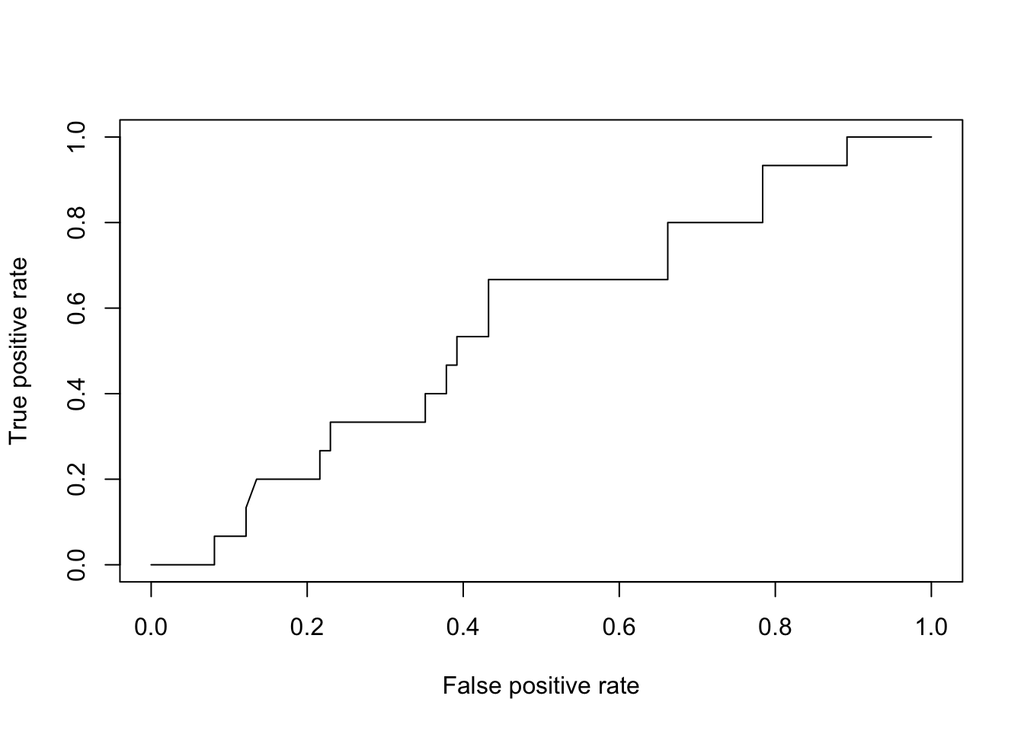

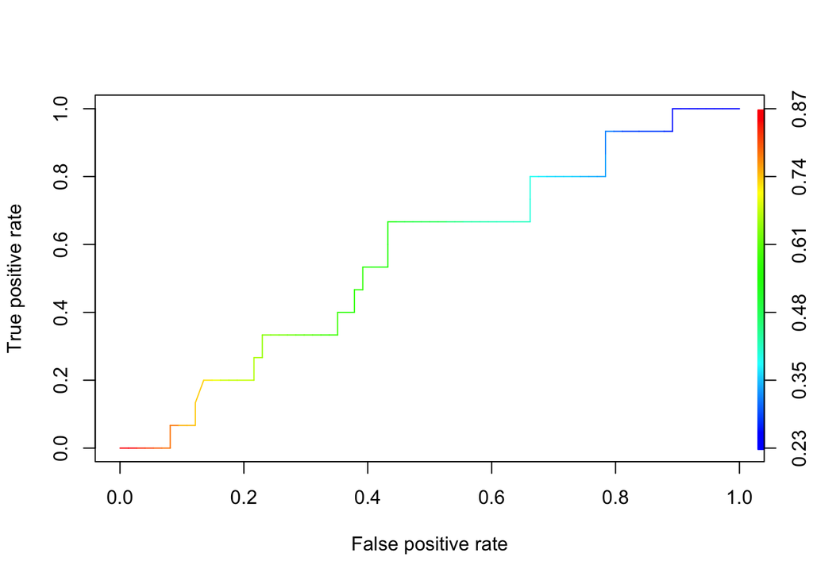

```
## [1] "AUC Score for Model 2 = 0.563513513513514"
```

A perfect model for a ROC Curve, would have the plot hugging the top left of the plot. The nearer the curve is to this, the better the model. Also the higher the AUC value (Area under the curve) the better the model (a perfect model would be equal to 1)